# Predicting with trees

## Key ideas

- Iteratively split variables into groups
- Evaluate “homogeneity” within each group
- Split again if necessary

### Pros

- Easy to interpret
- Better performance in nonlinear settings

### Cons

- Without pruning/cross-validation can lead to overfitting
- Harder to estimate uncertainty
- Results mey be variable

## Basic Algorithm

1. Start with all variables in one group
2. Find the variable/split that best separates the outcomes
3. Divide the data into two groups (“leaves”) on that split (“node”)
4. Within each split, find the best variable/split that separates the outcomes
5. Continue until the groups are too small or sufficiently “pure”

## Measures of impurity

Misclassification Error:
$$1 - \hat{p}_{m k(m)}; k(m) = {\rm most; common; k}$$

0 = perfect purity 0.5 = no purity Gini index:
$$\sum_{k \neq k'} \hat{p}{mk} \times \hat{p}{mk'} = \sum_{k=1}^K \hat{p}{mk}(1-\hat{p}{mk}) = 1 - \sum_{k=1}^K p_{mk}^2$$

0 = perfect purity 0.5 = no purity

## Measures of impurity

Deviance/information gain:

$$-\sum_{k=1}^K \hat{p}{mk} \log_2\hat{p}{mk}$$

0 = perfect purity 1 = no purity

http://en.wikipedia.org/wiki/Decision_tree_learning

## Measures of impurity

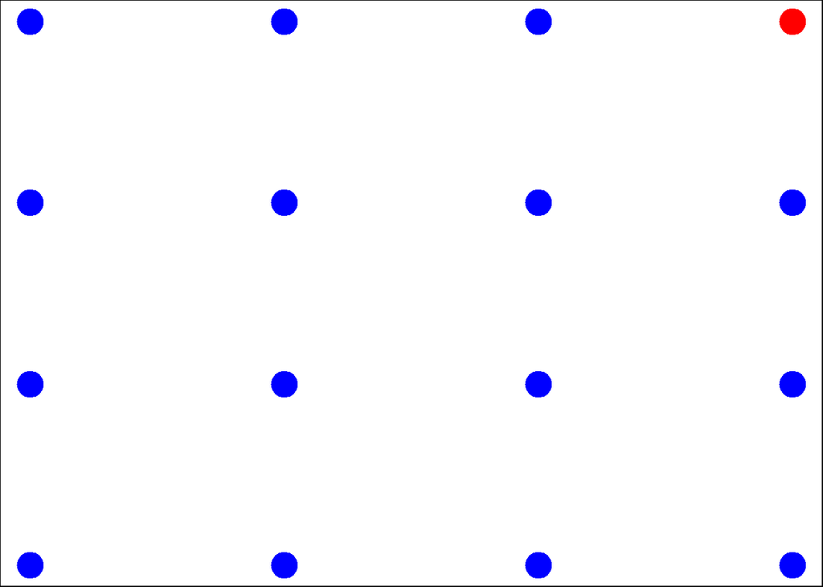

```r
par(mar=c(0,0,0,0)); set.seed(1234); x = rep(1:4,each=4); y = rep(1:4,4)
plot(x,y,xaxt="n",yaxt="n",cex=3,col=c(rep("blue",15),rep("red",1)),pch=19)
```

Misclassification: $1/16 = 0.06$  
Gini: $1 - [(1/16)^2 + (15/16)^2] = 0.12$  
Information:$-[1/16 \times log2(1/16) + 15/16 \times log2(15/16)] = 0.34$

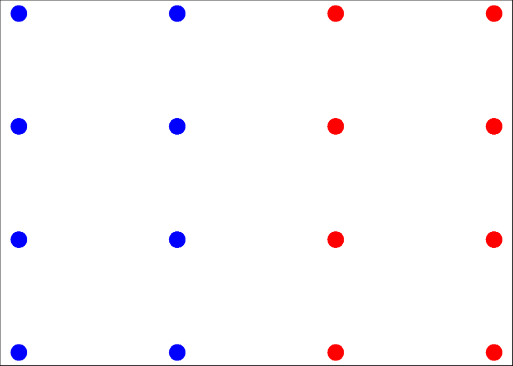

```r
par(mar=c(0,0,0,0));
plot(x,y,xaxt="n",yaxt="n",cex=3,col=c(rep("blue",8),rep("red",8)),pch=19)
```

## Example

```r
rm(list = ls())
data("iris")
library(ggplot2)
names(iris)
```

```
## [1] "Sepal.Length" "Sepal.Width"  "Petal.Length" "Petal.Width"
## [5] "Species"
```

```r
table(iris$Species)
```

```
##
##     setosa versicolor  virginica
##         50         50         50
```

### Create training and test sets

```r
library(caret)
inTrain <- createDataPartition(y=iris$Species,
                              p=0.7, list=FALSE)
training <- iris[inTrain,]
testing <- iris[-inTrain,]
dim(training)
```

```
## [1] 105   5
```

```r
dim(testing)
```

```
## [1] 45  5
```

### Iris petal widths/sepal width

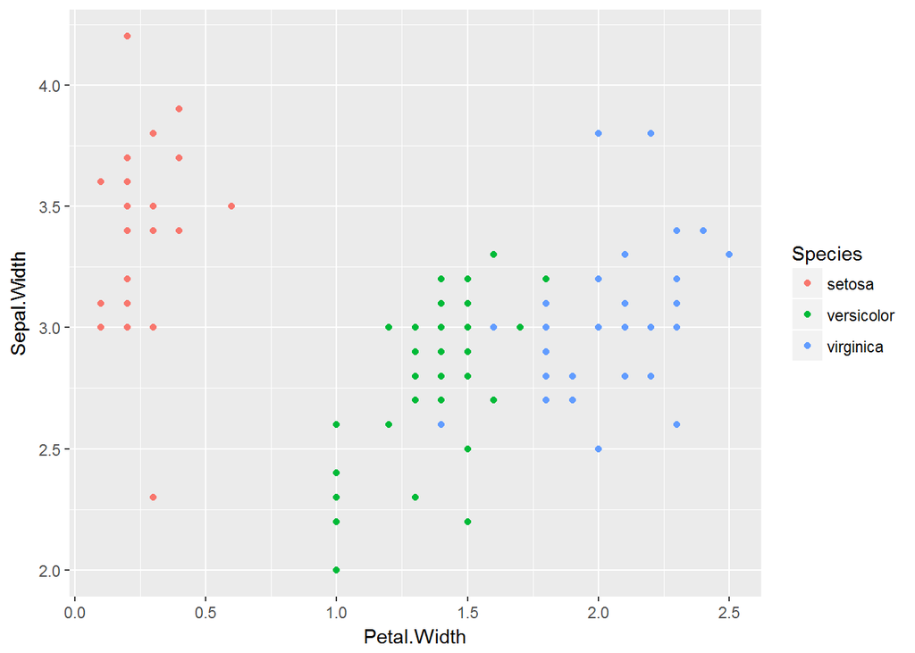

```r
qplot(Petal.Width,Sepal.Width,colour=Species,data=training)
```

### Iris petal widths/sepal width

```r
modFit <- train(Species ~ .,method="rpart",data=training)
print(modFit$finalModel)
```

```
## n= 105
##
## node), split, n, loss, yval, (yprob)
##       * denotes terminal node
##
## 1) root 105 70 setosa (0.33333333 0.33333333 0.33333333)
##   2) Petal.Length< 2.5 35  0 setosa (1.00000000 0.00000000 0.00000000) *
##   3) Petal.Length>=2.5 70 35 versicolor (0.00000000 0.50000000 0.50000000)
##     6) Petal.Width< 1.75 36  2 versicolor (0.00000000 0.94444444 0.05555556) *
##     7) Petal.Width>=1.75 34  1 virginica (0.00000000 0.02941176 0.97058824) *
```

### Plot tree

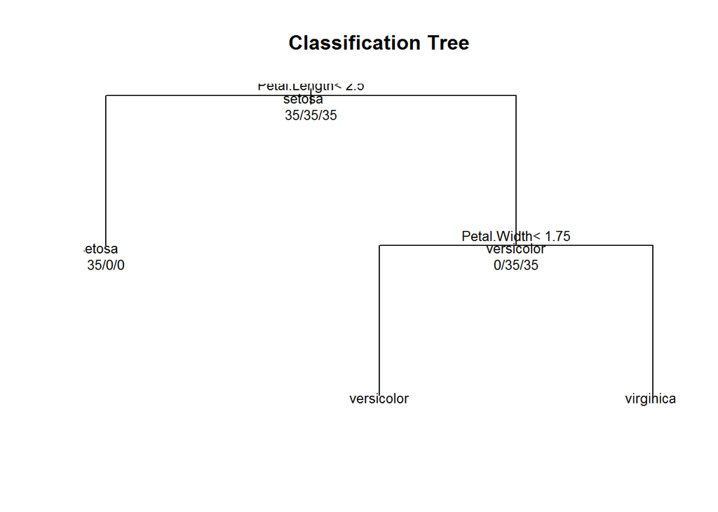

```r
plot(modFit$finalModel, uniform=TRUE,
      main="Classification Tree")
text(modFit$finalModel, use.n=TRUE, all=TRUE, cex=.8)
```

### Prettier plots

```r
library(rattle)
```

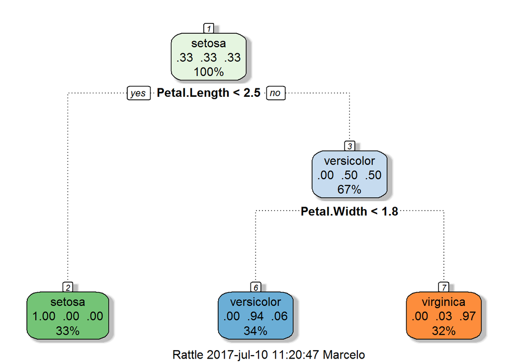

```r
fancyRpartPlot(modFit$finalModel)
```

### Predicting new values

```r
predict(modFit,newdata=testing)
```

```
##  [1] setosa     setosa     setosa     setosa     setosa     setosa
##  [7] setosa     setosa     setosa     setosa     setosa     setosa
## [13] setosa     setosa     setosa     versicolor versicolor versicolor
## [19] versicolor versicolor versicolor versicolor versicolor versicolor
## [25] versicolor versicolor versicolor versicolor versicolor versicolor
## [31] virginica  versicolor virginica  virginica  virginica  virginica
## [37] virginica  versicolor virginica  virginica  virginica  versicolor
## [43] virginica  virginica  virginica
## Levels: setosa versicolor virginica
```

## Notes and further resources

- Classification trees are non-linear models
- They use interactions between variables
- Data transformations may be less important (monotone transformations)
- Trees can also be used for regression problems (continuous outcome)
- Note that there are multiple tree building options in R both in the caret package - party, rpart and out of the caret package - tree  
  Books
- Introduction to statistical learning
- Elements of Statistical Learning
- Classification and regression trees